# CMString: a custom disease-focused NanoString based CMS classifier

Robert Piskol

2019-01-28

Four consensus molecular subtypes (CMS1-4) of colorectal cancer (CRC) defined by gene expression in mostly primary, early-stage tumors were identified and found to be associated with distinctive biological features and clinical outcomes. Given that distant metastasis largely accounts for CRC-related mortality, we sought to examine the molecular and clinical attributes of CMS in metastatic CRC (mCRC).

We have developed a custom disease-focused NanoString based CMS classifier that is ideally suited to interrogate archival tissues. Here we show how to apply this classifier to a set of early stage patient samples from the CIT data set as well as primary and metastatic samples from a procured set of patients with late stage disease.

This vignette is available by typing:

```
vignette(package = "CMString", topic = "vignette")
```

## Installation

Please follow the following instructions to install the package:

```
install.packages("devtools")
devtools::install_github("rpiskol/CMString")
```

Load the package once it is installed:

```r
library(CMString)
library(Biobase)
```

## Available data sets and their retrieval

Available data sets can be shown using the `showAvailableExpressionDataSets` function:

```r
showAvailableExpressionDataSets()
```

```
#> [1] "CIT"           "MVRM"          "Procured"      "crc.celllines"
```

Each of them can be loaded using the `getExpressionDataSet` function, which returns an `ExpressionSet` that contains the expression data as well as pheno data

```r
CIT.eset <- getExpressionDataSet(dataset = "CIT")
```

```
#> loading CIT dataset
```

```r
CIT.eset
```

```
#> ExpressionSet (storageMode: lockedEnvironment)
#> assayData: 20192 features, 566 samples
#>   element names: exprs, se.exprs
#> protocolData
#>   sampleNames: GSM971957 GSM971958 ... GSM972522 (566 total)
#>   varLabels: ScanDate
#>   varMetadata: labelDescription
#> phenoData
#>   sampleNames: GSM971957 GSM971958 ... GSM972522 (566 total)
#>   varLabels: Study Sample ... MSI (26 total)
#>   varMetadata: labelDescription
#> featureData
#>   featureNames: 1 10 ... 9997 (20192 total)
#>   fvarLabels: Gene.SYMBOL Gene.EG ... Probe.ID (6 total)
#>   fvarMetadata: labelDescription
#> experimentData: use 'experimentData(object)'
#> Annotation: hgu133plus2
```

```r
head(pData(CIT.eset), n=2)
```

```
#>           Study    Sample      GSE  Age Stage DFS.(months)
#> GSM971957   CIT GSM971957 GSE39582 34.5    IV           NA
#> GSM971958   CIT GSM971958 GSE39582 36.4    IV           NA
#>           DFS.status.(event=1) OS.(months) OS.status.(event=1)
#> GSM971957                   NA          10                   1
#> GSM971958                   NA           9                   1
#>           SAR.(months) SAR.status.(event=1)
#> GSM971957           NA                   NA
#> GSM971958           NA                   NA
#>           CMS_final_network_plus_RFclassifier_in_nonconsensus_samples
#> GSM971957                                                        CMS4
#> GSM971958                                                        CMS4
#>           CMS_network CMS_RFclassifier CMS.glmnet   CMS1.prob  CMS2.prob
#> GSM971957         UNK             CMS4       CMS1 0.490066722 0.09116985
#> GSM971958        CMS4             CMS4       CMS4 0.002545958 0.05722725
#>             CMS3.prob CMS4.prob Stage.group Age.group Sideness Gender
#> GSM971957 0.023879626 0.3948838    Stage IV       <65    Left       M
#> GSM971958 0.000154133 0.9400727    Stage IV       <65    Left       F
#>           braf_mutation kras_mutation MSI
#> GSM971957            wt             m MSS
#> GSM971958            wt            wt MSS
```

## CMS classification of CIT data

CMS classification can be performed using the `classifyCMString` function. The `thresh` parameter specifies the minimum confidence level to assign a CMS to a sample (e.g. the higher the `thresh` parameter, the higher the confidence has to be for assignment):

```r
classification <- classifyCMString(CIT.eset, thresh = .4)
```

```
#> assuming Entrez IDs as gene names
#> mediancenter
#> zScore
```

The resulting classification contains the predicted CMS subtypes and their probabilities.

```r
table(classification$clu.pred)
```

```
#>
#>   1   2   3   4
#> 100 246  64 154
```

```r
head(classification$pred)
```

```
#>                      1            2            3            4
#> GSM971957 0.4900667218 0.0911698464 2.387963e-02 0.3948838060
#> GSM971958 0.0025459585 0.0572272451 1.541330e-04 0.9400726634
#> GSM971959 0.2621236387 0.1341293511 6.020055e-01 0.0017414771
#> GSM971960 0.0013558198 0.9847415775 1.324610e-02 0.0006565021
#> GSM971961 0.0009088477 0.0004173377 7.922856e-05 0.9985945860
#> GSM971962 0.0501919351 0.0001853736 2.455724e-04 0.9493771189
```

We can add the predicted CMS subtypes back to the pheno data:

```r
CMS.glmnet <- classification$clu.pred[sampleNames(CIT.eset)]
CIT.eset$CMS.glmnet <- ifelse(is.na(CMS.glmnet), "UNK",
                                                 paste0("CMS",CMS.glmnet))
```

The distribution of CMS subtypes can be plotted as a pie chart:

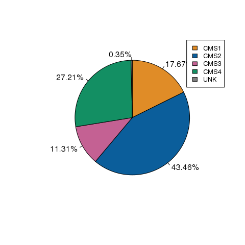

```
#>
#>  CMS1  CMS2  CMS3  CMS4   UNK
#> 17.67 43.46 11.31 27.21  0.35
```

```r
pieChart(pData(CIT.eset), digits = 2)
```

The predicted CMS types can be compared to the “Gold Standard” Network classification by Guinney et al ([see here](https://www.ncbi.nlm.nih.gov/pubmed/26457759)) using the `plotContingencyGeneral` function:

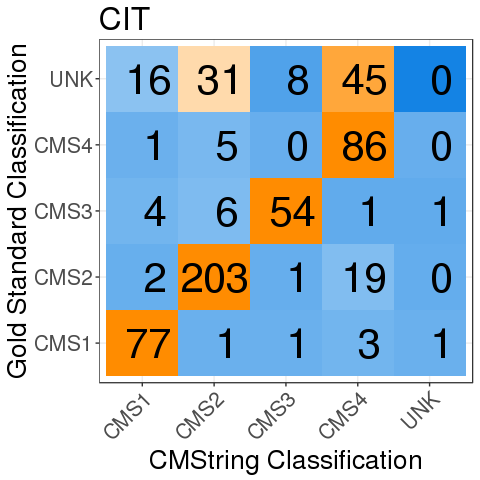

```
#> total elements with shared labels           elements on the diagnal
#>                       566.0000000                       420.0000000
#>             off-diagonal elements                       concordance
#>                       146.0000000                         0.7420495
```

```r
plotContingencyGeneral(CIT.eset$CMS.glmnet,
                       CIT.eset$CMS_network,
                       xlab="CMString Classification",
                       ylab="Gold Standard Classification",
                       main = "CIT")
```

The classification and expression data can also be plotted as a heat map with CMS annotation and prediction probabilties using the `figClassifyCMS` function:

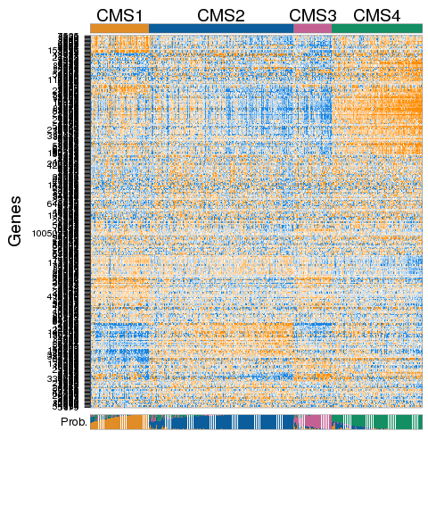

```r
figClassifyCMS(x=classification)
```

Gene and sample names can be toggled on/off:

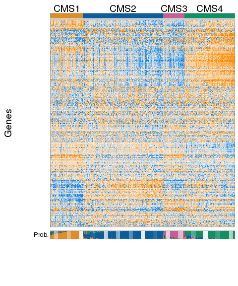

```r
figClassifyCMS(x=classification,gene.labs = FALSE, samp.labs = FALSE)
```

Instead of providing the result of the clustering procedure, also each element of the clustering result can be provided separately. This allows to modify the ordering of genes (determined by the hierarchical clustering in `gclus.f`) or samples (determined by `nam.ord`)

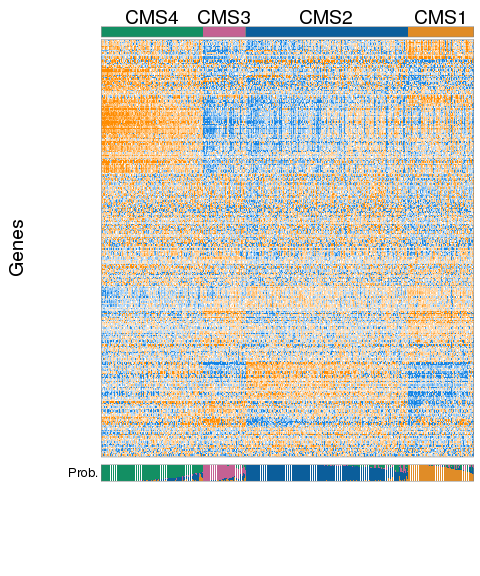

```r
figClassifyCMS(pred = classification$pred,
               clu.pred = classification$clu.pred,
               sdat.sig = classification$sdat.sig,
               gclu.f = rev(classification$gclu.f),
               nam.ord = rev(classification$nam.ord),
               missing.genes = classification$missing.genes,
               cex.axis.labs = 0.5, gene.labs = FALSE,samp.labs = FALSE)
```

## CMS classification of Procured samples

Our procured data set from late stage CRC patients consist of 312 samples. These include 182 primary samples and 130 metastases. The samples have been profiled using a custom probe set that allows to determine the expression of ~800 disease related genes.

```r
Procured.eset <- getExpressionDataSet(dataset = "Procured")
```

```
#> loading Procured dataset
```

```r
table(Procured.eset$Type)
```

```
#>
#>     Met Primary
#>     130     182
```

We can use either gene symbols or Entrez gene IDs for classification. In addition, the classification function accepts not only ExpressionSets but also gene expression matrices and data frames as input.

```r
# classification using Entrez IDs
Procured.exprs.entrez <- exprs(Procured.eset)
rownames(Procured.exprs.entrez) <- fData(Procured.eset)$Entrez
Procured.classification.entrez <- classifyCMString(Procured.exprs.entrez, thresh=.5)
```

```
#> assuming Entrez IDs as gene names
#> mediancenter
#> zScore
```

```r
# classification using Symbols
Procured.exprs.symbol <- exprs(Procured.eset)
rownames(Procured.exprs.symbol) <- fData(Procured.eset)$Symbol
Procured.classification.symbol <- classifyCMString(Procured.exprs.symbol, thresh=.5)
```

```
#> assuming Symbols as gene names
#> mediancenter
#> zScore
```

```r
xtabs(~Procured.classification.symbol$clu.pred + Procured.classification.entrez$clu.pred)
```

```
#>                                        Procured.classification.entrez$clu.pred
#> Procured.classification.symbol$clu.pred   1   2   3   4
#>                                       1  39   0   0   0
#>                                       2   0 143   0   0
#>                                       3   0   0  20   0
#>                                       4   0   0   0  83
```

As previously, a pie chart of CMS distributions and heatmap can be generated:

```r
CMS.glmnet <- Procured.classification.entrez$clu.pred[sampleNames(Procured.eset)]
Procured.eset$CMS.glmnet <- ifelse(is.na(CMS.glmnet), "UNK", paste0("CMS",CMS.glmnet))

# plot pie chart
pieChart(pData(Procured.eset), digits = 0)
```

```
#>
#> CMS1 CMS2 CMS3 CMS4  UNK
#>   12   46    6   27    9
```

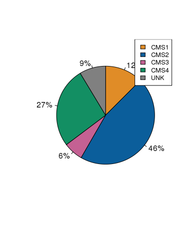

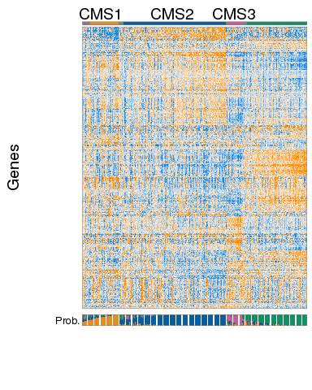

```r
# plot heatmap for all samples
figClassifyCMS(x=Procured.classification.entrez,gene.labs = FALSE, samp.labs = FALSE)
```

We can discard low-confidence predictions using the `subsetSamplesBySignificance` function:

```r
Procured.classification.entrez.highConf <- subsetSamplesBySignificance(Procured.classification.entrez, thresh=.5)
```

Given that the Procured data set contains primary samples and metastases it might be desirable to separate predictions into these two. This can be achieved using the `subsetSamplesByName` function:

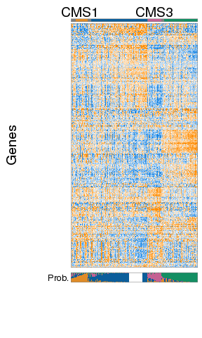

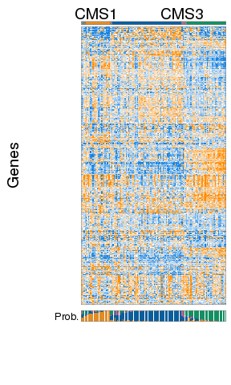

```r
sampids.primary <- Procured.eset$Sample[which(Procured.eset$Type == "Primary")]
sampids.met <- Procured.eset$Sample[which(Procured.eset$Type == "Met")]

Procured.classification.entrez.primary <- subsetSamplesByName(Procured.classification.entrez,
                                                              sampids.primary)
Procured.classification.entrez.met <- subsetSamplesByName(Procured.classification.entrez,
                                                          sampids.met)

# plot heatmap for primary samples
figClassifyCMS(x=Procured.classification.entrez.primary, gene.labs = FALSE)
# plot heatmap for metastases
figClassifyCMS(x=Procured.classification.entrez.met, gene.labs = FALSE)
```

## Retrieval of classifier features

Classifier features can be retrieved individually for each sybtype using the `getSignatureGenesPerCMS` function. If desired, they can then be combined into one list. Furthermore, features can be retrieved either in form of Entrez gene IDs or gene symbols.

```r
# as Entrez IDs
ids.entrez <- lapply(1:4,function(i){getSignatureGenesPerCMS(i, "Entrez" ,"lambda.min")})

# as Symbols
ids.symbol <- lapply(1:4,function(i){getSignatureGenesPerCMS(i, "Symbol" ,"lambda.min")})

sapply(ids.entrez, length)
```

```
#> [1] 110 115 108 127
```

```r
sapply(ids.symbol, length)
```

```
#> [1] 110 115 108 127
```

```r
length(unique(unlist(ids.symbol)))
```

```
#> [1] 322
```

```r
sort(unique(unlist(ids.symbol)))
```

```
#>   [1] "ABCC9"     "ACVR1"     "ACVR1C"    "ACVRL1"    "ADCY7"
#>   [6] "ADGRB1"    "ADGRB3"    "ADGRL4"    "AGR2"      "AIFM3"
#>  [11] "AMER1"     "APC"       "APCDD1"    "APH1A"     "APLN"
#>  [16] "APOL6"     "APPBP2"    "AREG"      "ARID1A"    "ARID3A"
#>  [21] "ASCL2"     "ASTE1"     "ATAD2"     "ATR"       "AXIN2"
#>  [26] "BAG2"      "BAX"       "BAZ2B"     "BCAM"      "BCL2A1"
#>  [31] "BCL2L11"   "BIRC5"     "BMP2"      "BMP4"      "BMPR1A"
#>  [36] "BMPR1B"    "BNC2"      "BRINP3"    "BRPF1"     "BTG3"
#>  [41] "CASP8"     "CASP9"     "CBLC"      "CCL5"      "CCNB1"
#>  [46] "CCNE2"     "CCR5"      "CD247"     "CD36"      "CD3E"
#>  [51] "CD40LG"    "CD44"      "CD70"      "CDC45"     "CDCA5"
#>  [56] "CDCA7L"    "CDH3"      "CDHR1"     "CDK6"      "CDK8"
#>  [61] "CDKN1B"    "CDKN2A"    "CDKN2B"    "CENPM"     "CES1"
#>  [66] "CES2"      "CHEK2"     "CLEC14A"   "CLEC5A"    "CNTNAP2"
#>  [71] "COL15A1"   "COL18A1"   "COL6A3"    "COL7A1"    "COPB2"
```

[output cut: 50 more lines]